# R Notebook

```r
avocado <- read_csv("data/avocado.csv")
summary(avocado)
```

[output not shown]

[output cut: 990 more lines]

In this study, it is interesting to model the average avocado price (**average_price**) with respect to some predictor variables, such as total volume of avocados sold in a specific period (e.g. week or a month), type of avocados, the city of observation (where they coming from).

To start with, the variable **type** is converted to a logical vector.

| x1 | date | average_price | total_volume | x4046 | x4225 | x4770 | total_bags | small_bags | large_bags | x_large_bags | type | year | region |
| --- | --- | --- | --- | --- | --- | --- | --- | --- | --- | --- | --- | --- | --- |
| 0 | 2015-12-27 | 1.33 | 64236.62 | 1036.74 | 54454.85 | 48.16 | 8696.87 | 8603.62 | 93.25 | 0.00 | TRUE | 2015 | Albany |
| 1 | 2015-12-20 | 1.35 | 54876.98 | 674.28 | 44638.81 | 58.33 | 9505.56 | 9408.07 | 97.49 | 0.00 | TRUE | 2015 | Albany |
| 2 | 2015-12-13 | 0.93 | 118220.22 | 794.70 | 109149.67 | 130.50 | 8145.35 | 8042.21 | 103.14 | 0.00 | TRUE | 2015 | Albany |
| 3 | 2015-12-06 | 1.08 | 78992.15 | 1132.00 | 71976.41 | 72.58 | 5811.16 | 5677.40 | 133.76 | 0.00 | TRUE | 2015 | Albany |
| 4 | 2015-11-29 | 1.28 | 51039.60 | 941.48 | 43838.39 | 75.78 | 6183.95 | 5986.26 | 197.69 | 0.00 | TRUE | 2015 | Albany |
| 5 | 2015-11-22 | 1.26 | 55979.78 | 1184.27 | 48067.99 | 43.61 | 6683.91 | 6556.47 | 127.44 | 0.00 | TRUE | 2015 | Albany |
| 6 | 2015-11-15 | 0.99 | 83453.76 | 1368.92 | 73672.72 | 93.26 | 8318.86 | 8196.81 | 122.05 | 0.00 | TRUE | 2015 | Albany |
| 7 | 2015-11-08 | 0.98 | 109428.33 | 703.75 | 101815.36 | 80.00 | 6829.22 | 6266.85 | 562.37 | 0.00 | TRUE | 2015 | Albany |
| 8 | 2015-11-01 | 1.02 | 99811.42 | 1022.15 | 87315.57 | 85.34 | 11388.36 | 11104.53 | 283.83 | 0.00 | TRUE | 2015 | Albany |
| 9 | 2015-10-25 | 1.07 | 74338.76 | 842.40 | 64757.44 | 113.00 | 8625.92 | 8061.47 | 564.45 | 0.00 | TRUE | 2015 | Albany |

[output cut: 990 more lines]

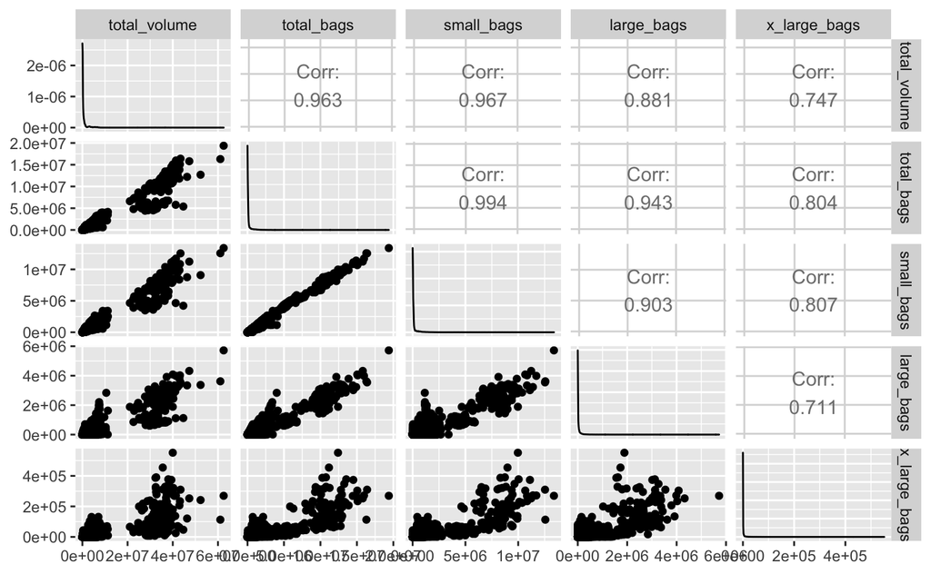

As can be seen, all the considered variables are strongly correlated. For example, the r value between total bags and small bags is 0.99 whereas the r value between total volume and small bags is 0.97. For this reason, the variables small, large and extra large bags will not be considered in the study.

It is now interesting to compare the **average price** variable with the total volume of avocados sold.

```r
avocado_new %>%
  ggplot(aes(x = total_volume, y = average_price)) +
  geom_point()
```

[output not shown]

The average price has a negative correlation value of 0.19 with respect to the total volume of avocados sold.

| cor(average_price, total_volume) |
| --- |
| -0.1927524 |

Now let’s run the regression and diagnostics:

```r
model <- lm(average_price ~ total_volume, data = avocado_new)
summary(model)
```

```
Call:
lm(formula = average_price ~ total_volume, data = avocado_new)

Residuals:
     Min       1Q   Median       3Q      Max
-0.98366 -0.29994 -0.03319  0.25498  1.82528

Coefficients:
               Estimate Std. Error t value Pr(>|t|)
(Intercept)   1.425e+00  3.012e-03  473.07   <2e-16 ***
total_volume -2.247e-08  8.470e-10  -26.54   <2e-16 ***
---
Signif. codes:  0 ‘***’ 0.001 ‘**’ 0.01 ‘*’ 0.05 ‘.’ 0.1 ‘ ’ 1

Residual standard error: 0.3951 on 18247 degrees of freedom
Multiple R-squared:  0.03715,   Adjusted R-squared:  0.0371
F-statistic: 704.1 on 1 and 18247 DF,  p-value: < 2.2e-16
```

As can be seen, there is a very small value of r^2, 0.04, but the p-value of the total volume coefficient indicates that the predictor is significant.

It will be now interesting to compare the two types of avocados, conventional and organic. A box plot will show the comparison:

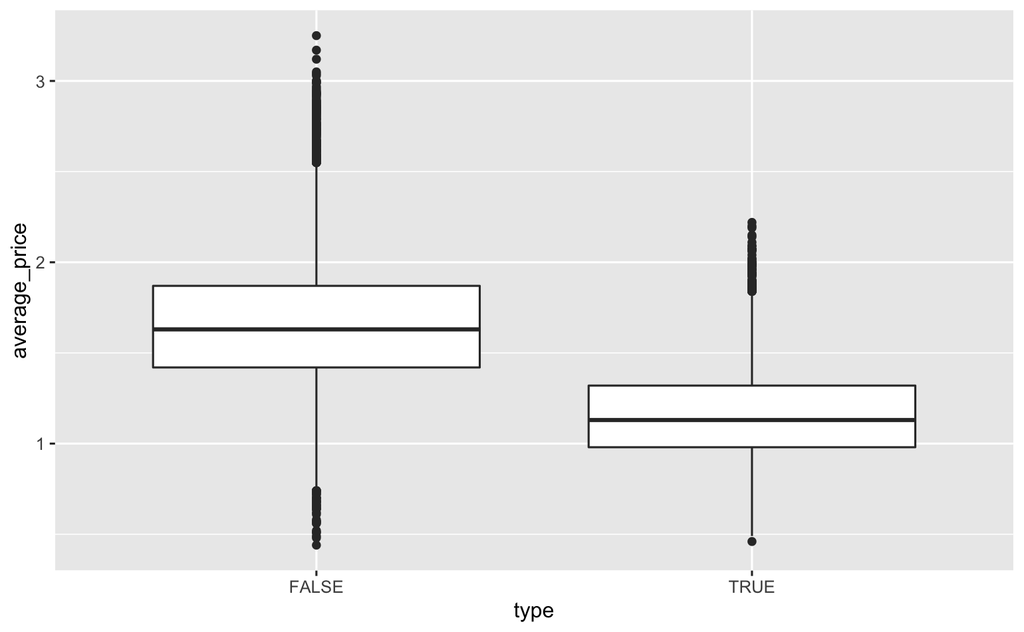

```r
model2<- lm(average_price ~ total_volume + type, data = avocado_new)
summary(model2)
```

```
Call:
lm(formula = average_price ~ total_volume + type, data = avocado_new)

Residuals:
     Min       1Q   Median       3Q      Max
-1.21390 -0.20314 -0.02548  0.18575  1.59581

Coefficients:
               Estimate Std. Error  t value Pr(>|t|)
(Intercept)   1.654e+00  3.315e-03  499.042   <2e-16 ***
total_volume -6.115e-09  6.978e-10   -8.763   <2e-16 ***
typeTRUE     -4.861e-01  4.819e-03 -100.872   <2e-16 ***
---
Signif. codes:  0 ‘***’ 0.001 ‘**’ 0.01 ‘*’ 0.05 ‘.’ 0.1 ‘ ’ 1

Residual standard error: 0.3166 on 18246 degrees of freedom
Multiple R-squared:  0.3819,    Adjusted R-squared:  0.3818
F-statistic:  5636 on 2 and 18246 DF,  p-value: < 2.2e-16
```

As can be seen, the r^2 has been increased from 0.04 to 0.38. The p-values are 0, which indicates that the predictor variables are significant

```r
ggpairs(avocado_new[,c("average_price","type", "year", "date")])
```

[output not shown]

```r
model3<- lm(average_price ~ total_volume + type + region + date, data = avocado_new)
summary(model3)
```

```
Call:
lm(formula = average_price ~ total_volume + type + region + date,
    data = avocado_new)

Residuals:
     Min       1Q   Median       3Q      Max
-1.07682 -0.16135 -0.00603  0.14722  1.47303

Coefficients:
                            Estimate Std. Error  t value Pr(>|t|)
(Intercept)               -1.120e+00  9.883e-02  -11.334  < 2e-16 ***
total_volume              -3.190e-09  8.331e-10   -3.829 0.000129 ***
typeTRUE                  -4.908e-01  4.142e-03 -118.479  < 2e-16 ***
regionAtlanta             -2.224e-01  2.037e-02  -10.917  < 2e-16 ***
regionBaltimoreWashington -2.569e-02  2.037e-02   -1.261 0.207405
regionBoise               -2.129e-01  2.037e-02  -10.452  < 2e-16 ***
regionBoston              -2.938e-02  2.037e-02   -1.442 0.149233
regionBuffaloRochester    -4.414e-02  2.037e-02   -2.167 0.030271 *
regionCalifornia          -1.562e-01  2.052e-02   -7.609 2.90e-14 ***
regionCharlotte            4.518e-02  2.037e-02    2.218 0.026558 *
regionChicago             -3.150e-03  2.037e-02   -0.155 0.877114
regionCincinnatiDayton    -3.516e-01  2.037e-02  -17.259  < 2e-16 ***
regionColumbus            -3.081e-01  2.037e-02  -15.126  < 2e-16 ***
regionDallasFtWorth       -4.736e-01  2.038e-02  -23.245  < 2e-16 ***
regionDenver              -3.413e-01  2.037e-02  -16.753  < 2e-16 ***
regionDetroit             -2.845e-01  2.037e-02  -13.966  < 2e-16 ***
regionGrandRapids         -5.590e-02  2.037e-02   -2.744 0.006070 **
regionGreatLakes          -2.171e-01  2.042e-02  -10.631  < 2e-16 ***
regionHarrisburgScranton  -4.751e-02  2.037e-02   -2.332 0.019699 *
regionHartfordSpringfield  2.579e-01  2.037e-02   12.662  < 2e-16 ***
regionHouston             -5.113e-01  2.038e-02  -25.096  < 2e-16 ***
regionIndianapolis        -2.469e-01  2.037e-02  -12.121  < 2e-16 ***
regionJacksonville        -4.997e-02  2.037e-02   -2.453 0.014176 *
regionLasVegas            -1.798e-01  2.037e-02   -8.824  < 2e-16 ***
regionLosAngeles          -3.404e-01  2.041e-02  -16.681  < 2e-16 ***
regionLouisville          -2.743e-01  2.037e-02  -13.468  < 2e-16 ***
regionMiamiFtLauderdale   -1.318e-01  2.037e-02   -6.469 1.01e-10 ***
regionMidsouth            -1.516e-01  2.041e-02   -7.430 1.13e-13 ***
regionNashville           -3.488e-01  2.037e-02  -17.121  < 2e-16 ***
regionNewOrleansMobile    -2.560e-01  2.037e-02  -12.565  < 2e-16 ***
```

[output cut: 18 more lines]

```
regionSoutheast           -1.574e-01  2.042e-02   -7.705 1.38e-14 ***
regionSpokane             -1.154e-01  2.037e-02   -5.668 1.47e-08 ***
regionStLouis             -1.303e-01  2.037e-02   -6.395 1.65e-10 ***
regionSyracuse            -4.076e-02  2.037e-02   -2.001 0.045420 *
regionTampa               -1.517e-01  2.037e-02   -7.448 9.91e-14 ***
regionTotalUS             -1.868e-01  2.496e-02   -7.486 7.43e-14 ***
regionWest                -2.787e-01  2.054e-02  -13.569  < 2e-16 ***
regionWestTexNewMexico    -2.957e-01  2.042e-02  -14.483  < 2e-16 ***
date                       1.719e-04  5.741e-06   29.943  < 2e-16 ***
---
Signif. codes:  0 ‘***’ 0.001 ‘**’ 0.01 ‘*’ 0.05 ‘.’ 0.1 ‘ ’ 1

Residual standard error: 0.2648 on 18192 degrees of freedom
Multiple R-squared:  0.5688,    Adjusted R-squared:  0.5675
F-statistic: 428.6 on 56 and 18192 DF,  p-value: < 2.2e-16
```

In this study, we conclude that the **average price of avocados** can be explained or affected by the total volume of avocados sold, the type of avocados, their region of origin and the date where they are sold.